# clustering step by step

Mo’men Mohamed

December 16, 2018

```r
library(magrittr)
```

## This tutorial aim

This tutorial aims to illustrate all steps and process to do a three types of clustering

1- K-means clustering

2- Hierarchical clustering

3- DBSCAN Clustering

## The Overall steps

Our steps are rounded to a specified steps :

1- measuring the tendency of the data to clustering

2- identifying the optimum number of clusters

3- measuring the Validity of current model

##Data description

We will work with *iris* data from **datasets** package

```r
data("iris")
```

this data have a dimension of **150, 5**

lets explore its structure

```r
str(iris)
```

```
## 'data.frame':    150 obs. of  5 variables:
##  $ Sepal.Length: num  5.1 4.9 4.7 4.6 5 5.4 4.6 5 4.4 4.9 ...
##  $ Sepal.Width : num  3.5 3 3.2 3.1 3.6 3.9 3.4 3.4 2.9 3.1 ...
##  $ Petal.Length: num  1.4 1.4 1.3 1.5 1.4 1.7 1.4 1.5 1.4 1.5 ...
##  $ Petal.Width : num  0.2 0.2 0.2 0.2 0.2 0.4 0.3 0.2 0.2 0.1 ...
##  $ Species     : Factor w/ 3 levels "setosa","versicolor",..: 1 1 1 1 1 1 1 1 1 1 ...
```

we can see that the data contains 4 variables represent four dimension for clustering

we can examine it in depth and see its summary

```r
summary(iris[,c("Sepal.Length","Sepal.Width","Petal.Length","Petal.Width")])
```

```
##   Sepal.Length    Sepal.Width     Petal.Length    Petal.Width
##  Min.   :4.300   Min.   :2.000   Min.   :1.000   Min.   :0.100
##  1st Qu.:5.100   1st Qu.:2.800   1st Qu.:1.600   1st Qu.:0.300
##  Median :5.800   Median :3.000   Median :4.350   Median :1.300
##  Mean   :5.843   Mean   :3.057   Mean   :3.758   Mean   :1.199
##  3rd Qu.:6.400   3rd Qu.:3.300   3rd Qu.:5.100   3rd Qu.:1.800
##  Max.   :7.900   Max.   :4.400   Max.   :6.900   Max.   :2.500
```

OK! the data doesn’t contains any Na’s

So, lets start our first step:

## measuring the tendency to clustring

We Will use a Hopkins Statistic from *clusterend* package

```r
library(clustertend)
```

Now let’s calculate it on the Original data:

```r
hopkins(data = iris[,c("Sepal.Length","Sepal.Width","Petal.Length","Petal.Width")],n = nrow(iris)-1)%>%print()
```

```
## $H
## [1] 0.1810226
```

Hopkins statistics is close to **Zero** and it means that the data is significantly clustered

And to see the difference between cluster-able and not cluster-able data lets make a simulation and building a random data frame

```r
set.seed(123)
x<-runif(n = nrow(iris),min = min(iris$Sepal.Length),max = max(iris$Sepal.Length))
y<-runif(n = nrow(iris),min = min(iris$Sepal.Width),max=max(iris$Sepal.Width))
w<-runif(n = nrow(iris),min = min(iris$Petal.Length),max=max(iris$Petal.Length))
z<-runif(n = nrow(iris),min = min(iris$Petal.Width),max=max(iris$Petal.Width))

random_df<-data.frame(x,y,w,z)
```

```r
saveRDS(object = random_df,file = './data sets/random.rds')
```

Now lets calculate the Hopkins statistic on random data doesn’t have the clustering tendency

```r
hopkins(data = random_df,n = nrow(random_df)-1)%>%print()
```

```
## $H
## [1] 0.4941232
```

see !

the random data takes a larger statistic than the original data which is close to zero

for more about **Hopkin’s statistic** see this [tutorial](http://www.sthda.com/english/wiki/print.php?id=238)

## Knowing the Optimum number of clusters

### Kmeans clustering

to know that there are two ways - Analyzing the total within SS error - silhouette index

let’s analyse the gap between total within SS error of each number of clusters

```r
tot_within<-list()

for(i in 1:50){
        km<-kmeans(x = iris[,1:4],centers = i,nstart = 25)
        tot_within[[i]]<-km$tot.withinss
}
```

Now let us plot the tot.withinss against number of clusters

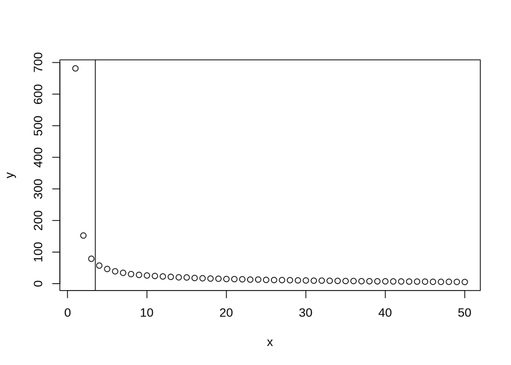

```r
y=unlist(tot_within)
x=1:50
plot(x = x,y=y)
abline(v = 3.5)
```

from the plot we can see that the minimum difference in total within SS error achieved at 3 clusters

and we can conclude that the data has 3 clusters

but why not to try another parameter which is **silhouette index** to make confirm

```r
scaled_iris<-scale(x = iris[,1:4])

dist_iris<-dist(scaled_iris)
```

Now we can calculate the silhouette index using *cluster* package

```r
library(cluster)
```

And calculate the index

```r
avg_sil<-list()
for(i in 2:60){
        km<-kmeans(x = iris[,1:4],centers = i,nstart = 25)
        sil<-silhouette(x = km$cluster,dist = dist_iris)
        sil_summary<-summary(sil)
        avg_sil[[i]]<-sil_summary$avg.width
}
```

and then plot the sil_summary

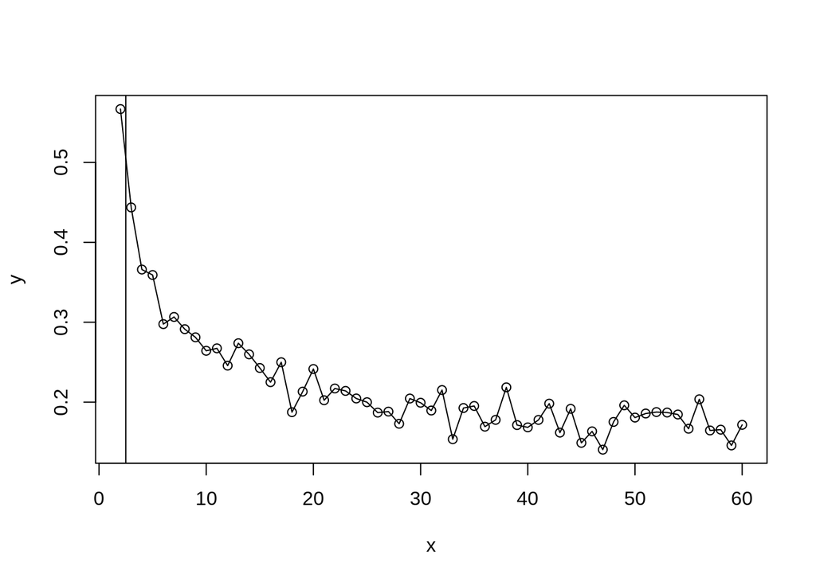

```r
x=2:60
y=unlist(avg_sil)
plot(x=x,y=y)
lines(x,y)
abline(v = 2.5)
```

from the plot we can see that the highest silhouette index achieved at 2 clusters

for more about silhouette index concept see wikipedia

OK but which number of cluster we will take ?

OK lets make tricky thing

lets compare the predefined cluster introduced by the data and the clusters we introduce !!

```r
km<-kmeans(x = iris[,1:4],centers = 3,nstart = 25)

iris$clusters<-km$cluster

table(iris$cluster,iris$Species)
```

```
##
##     setosa versicolor virginica
##   1      0         48        14
##   2      0          2        36
##   3     50          0         0
```

```r
km<-kmeans(x = iris[,1:4],centers = 2,nstart = 25)

iris$clusters<-km$cluster

table(iris$cluster,iris$Species)
```

```
##
##     setosa versicolor virginica
##   1      0         47        50
##   2     50          3         0
```

Form the two comparison we can see that *versicolor & virginica* have a great share in cluster “1”

So it is better to divide it into two clusters !!!

Finally , we can assure the validation of our decision Visually through **ordered dissimilarity image**

**Note** : we can use it also to assess cluster tendency ( ** visual assessment of cluster tendency (VAT)**)

we will use *seriation* package

```r
library(seriation)
```

Now we Can do this by *dissplot()*

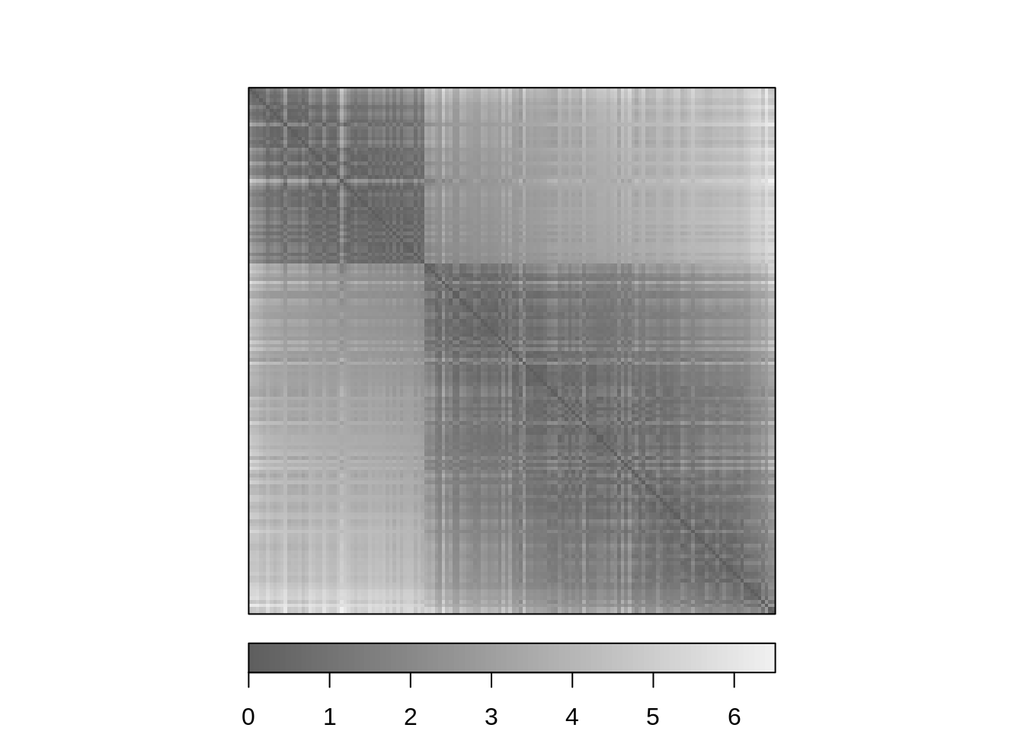

```r
dissplot(x = dist_iris)
```

From this plot we can see that the data has a tendency to clustering with a valid 2 cluster …

####Note that the conflict between the optimum number of clusters may be due to the method of clustering it self, as Kmeans is a technique which aim to devide the data set to non overlabing clusters (*partitional clustring*) the thing which is not accurate here as it may be a nested cluster under other one ** Heirarchical Clusters**

### Heirarchical clustering

Knowing the optimum number of clusters in H-clustering is somewhat similar to Kmeans as we can use sillhouette index like the following

```r
hc<-hclust(d = dist_iris,method = 'average')
```

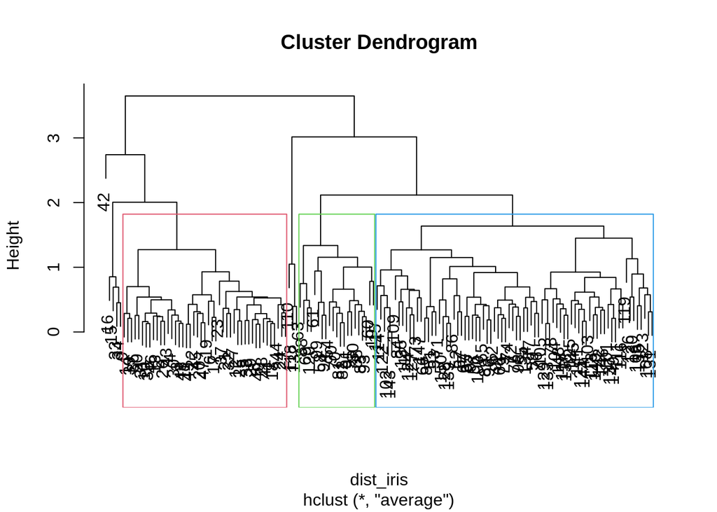

```r
plot(hc)
rect.hclust(tree = hc,k = 6,which = c(3,5,6),border = 2:5)
```

```r
avg_sil<-list()
for(i in 2:60){
        cutted<-cutree(tree = hc,k = i)
        sil<-silhouette(x = cutted,dist = dist_iris)
        sil_summary<-summary(sil)
        avg_sil[[i]]<-sil_summary$avg.width
}
```

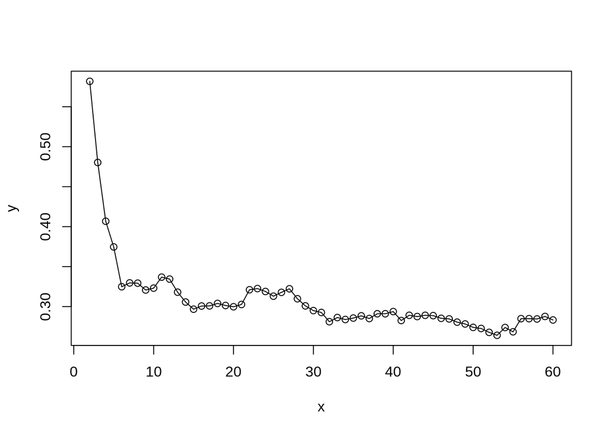

```r
x=2:60
y=unlist(avg_sil)

plot(x=x,y=y)
lines(x=x,y=y)
```

See !! there are agreement between the two type of clustering on 2 clusters

Regarding to H-clustering there are a method used to determined the best method of clustering (**“single”**,**“complete”**,**“average”**) called cophenetics correlation coefficient *(cpcc)*

Lets see how we can exploit it to determine the best method of H-clustering

```r
cop_list<-list()

for( i in c( "ward.D", "ward.D2", "single", "complete", "average", "mcquitty","centroid")){
        hc<-hclust(dist_iris,method = i)

        dist_coph<-cophenetic(x = hc)

        cop_list[[i]]<-cor(dist_iris,dist_coph)
}

print(cop_list)
```

```
## $ward.D
## [1] 0.8070321
##
## $ward.D2
## [1] 0.8226304
##
## $single
## [1] 0.830005
##
## $complete
## [1] 0.7514592
##
## $average
## [1] 0.8543606
##
## $mcquitty
## [1] 0.7159064
##
## $centroid
## [1] 0.8471218
```

from the correlation coefficient we can see tha the “single”,“average” and centroid method represent the best methods